# Assignment 2 - Language Development in ASD - Making predictions

Riccardo Fusaroli

August 9, 2019

## Welcome to the second exciting part of the Language Development in ASD exercise

In this exercise we will delve more in depth with different practices of model comparison and model selection, by first evaluating your models from last time against some new data. Does the model generalize well? Then we will learn to do better by cross-validating models and systematically compare them.

The questions to be answered (in a separate document) are: 1- Discuss the differences in performance of your model in training and testing data 2- Which individual differences should be included in a model that maximizes your ability to explain/predict new data? 3- Predict a new kid’s performance (Bernie) and discuss it against expected performance of the two groups

## Learning objectives

- Critically appraise the predictive framework (contrasted to the explanatory framework)
- Learn the basics of machine learning workflows: training/testing, cross-validation, feature selections

## Let’s go

N.B. There are several datasets for this exercise, so pay attention to which one you are using!

1. The (training) dataset from last time (the awesome one you produced :-) ).
2. The (test) datasets on which you can test the models from last time:
- Demographic and clinical data: https://www.dropbox.com/s/ra99bdvm6fzay3g/demo_test.csv?dl=1
- Utterance Length data: https://www.dropbox.com/s/uxtqqzl18nwxowq/LU_test.csv?dl=1
- Word data: https://www.dropbox.com/s/1ces4hv8kh0stov/token_test.csv?dl=1

### Exercise 1) Testing model performance

How did your models from last time perform? In this exercise you have to compare the results on the training data () and on the test data. Report both of them. Compare them. Discuss why they are different.

- recreate the models you chose last time (just write the model code again and apply it to your training data (from the first assignment))
- calculate performance of the model on the training data: root mean square error is a good measure. (Tip: google the function rmse())
- create the test dataset (apply the code from assignment 1 to clean up the 3 test datasets)
- test the performance of the models on the test data (Tips: google the functions “predict()”)
- optional: predictions are never certain, can you identify the uncertainty of the predictions? (e.g. google predictinterval())

The predictions for the training set gave us a root mean square value (rmse-value) of 0.3, which means that whenever we try to predict a value, we can expect an error of 0.3. This value is 3 times smaller then the SD that the mean makes when explaining the data. This suggests that our the model is much better than the null model. For the testing set, the root mean square value (rmse-value) was 0.5, which is a bit closer to the SD of 0.9, which suggests that our model is better, but still leaves error to be explained (0.4 to be exact).

### Exercise 2) Model Selection via Cross-validation (N.B: ChildMLU!)

One way to reduce bad surprises when testing a model on new data is to train the model via cross-validation.

In this exercise you have to use cross-validation to calculate the predictive error of your models and use this predictive error to select the best possible model.

- Use cross-validation to compare your model from last week with the basic model (Child MLU as a function of Time and Diagnosis, and don’t forget the random effects!)
- (Tips): google the function “createFolds”; loop through each fold, train both models on the other folds and test them on the fold)
- Now try to find the best possible predictive model of ChildMLU, that is, the one that produces the best cross-validated results.
- Bonus Question 1: What is the effect of changing the number of folds? Can you plot RMSE as a function of number of folds?
- Bonus Question 2: compare the cross-validated predictive error against the actual predictive error on the test data

```r
# First we change Child:ID to ensure that there isn't any overlapping ID's
Test$Child.ID <- as.integer(Test$Child.ID)
Test$Child.ID <- Test$Child.ID+1000

# Merging the 2 datasets to one big dataset
All_Data <- rbind(train, Test)

#- Create the basic model of ChildMLU as a function of Time and Diagnosis (don't forget the random effects!).
null_model <- lmer(CHI_MLU ~ Visit*Diagnosis + (1|Child.ID) + (0+Visit|Child.ID), data = All_Data)

#- Make a cross-validated version of the model. (Tips: google the function "createFolds";  loop through each fold, train a model on the other folds and test it on the fold)

folds <- createFolds(unique(All_Data$Child.ID), k=5,list = TRUE)
folds
```

```
## $Fold1
##  [1]  8 12 16 23 28 29 33 38 46 47 53 58 67
##
## $Fold2
##  [1]  1  4  7 15 24 25 32 37 44 45 48 51 56 62 66
##
## $Fold3
##  [1]  6  9 17 21 27 34 39 40 49 55 60 63 64
##
## $Fold4
##  [1]  2  3 13 22 26 30 35 41 42 52 54 59
##
## $Fold5
##  [1]  5 10 11 14 18 19 20 31 36 43 50 57 61 65
```

```r
#make counter
n = 1
#no data list
RMSETrain = NULL
RMSETest = NULL

for (i in folds) {
  TrainSub <- subset(All_Data, !(Child.ID%in%i))
  TestSub <- subset(All_Data, (Child.ID%in%i)) #put in test data if problem

  null_model <- lmer(CHI_MLU ~ Visit*Diagnosis + (1|Child.ID) + (0+Visit|Child.ID), data = TrainSub)
  train_predict <- predict(null_model)

  test_predict <- predict(null_model, newdata=TestSub, allow.new.levels = TRUE)

  RMSETrain[n]=rmse(TrainSub$CHI_MLU, train_predict)
  RMSETest[n]=rmse(TestSub$CHI_MLU, test_predict)
  n=n+1
}

RMSETrain
```

```
## [1] 0.3509747 0.3395127 0.3421624 0.3358904 0.3618692
```

```r
RMSETest
```

```
## [1] 0.8002458 0.6860893 0.7187887 0.8436771 0.7734145
```

```r
# Taking the mean of the test and train data to get numbers we can compare
mean(RMSETrain) #0.3461653
```

```
## [1] 0.3460818
```

```r
mean(RMSETest) #0.7483976
```

```
## [1] 0.7644431
```

```r
#- Now try to find the best possible predictive model of ChildMLU, that is, the one that produces the best cross-validated results.

folds <- createFolds(unique(All_Data$Child.ID), k=5,list = TRUE)
folds
```

```
## $Fold1
##  [1]  2  7  8  9 18 22 25 39 47 48 53 56 58 62
##
## $Fold2
##  [1]  4 10 11 12 20 21 30 34 36 40 50 52 54 64
##
## $Fold3
##  [1] 14 15 17 23 29 31 41 45 46 57 61 63 65
##
## $Fold4
##  [1]  3  6 16 19 24 26 33 37 38 43 44 59 60 67
##
## $Fold5
##  [1]  1  5 13 27 28 32 35 42 49 51 55 66
```

```r
#make counter
n = 1
#no data list
RMSETrain = NULL
RMSETest = NULL

for (i in folds) {
  TrainSub <- subset(All_Data, !(Child.ID%in%i))
  TestSub <- subset(All_Data, (Child.ID%in%i)) #put in test data if problem

  M8 <- lmer(CHI_MLU ~ Visit * Diagnosis * verbalIQ1 *types_CHI+ (1|Child.ID) + (0 + Visit|Child.ID), TrainSub)
  train_predict <- predict(M8)

  test_predict <- predict(M8, newdata=TestSub, allow.new.levels = TRUE)

  RMSETrain[n]=rmse(TrainSub$CHI_MLU, train_predict)
  RMSETest[n]=rmse(TestSub$CHI_MLU, test_predict)
  n=n+1
}
RMSETrain
```

```
## [1] 0.3012022 0.2921453 0.3155892 0.3104623 0.3052657
```

```r
RMSETest
```

```
## [1] 0.4854979 0.4911937 0.4573177 0.3955027 0.4157691
```

```r
# Taking the mean of the test and train data to get numbers we can compare
mean(RMSETrain) # 0.304862
```

```
## [1] 0.3049329
```

```r
mean(RMSETest) # 0.4464621
```

```
## [1] 0.4490562
```

```r
# calculating the
sd(All_Data$CHI_MLU)
```

```
## [1] 0.9282516
```

```r
#- Report the results and comment on them.
# The NUll model preforms well on training (RMSE = 0.35) but seems to overfit and thereby increase to RMSE = 0.76. The alternative model performes well on training (RMSE = 0.3) and doesn't increase much in testing (RMSE = 0.45). Models are assumed to be "good" if their RMSE values are a bit lower then the standard diviation of Child MLU (0.93).

# Bonus Question 1: What is the effect of changing the number of folds? Can you plot RMSE as a function of number of folds?
# Bonus Question 2: compare the cross-validated predictive error against the actual predictive error on the test data
```

The NUll model preforms good on training (RMSE = 0.35) but seems to overfit and thereby increase to RMSE = 0.76. The alternative model performes well on training ((RMSE = 0.3) and doesn’t increase much in testing ((RMSE = 0.45). Models are assumed to be “good” if their RMSE values are a bit lower then the standard diviation of Child MLU (0.93).

### Exercise 3) Assessing the single child

Let’s get to business. This new kiddo - Bernie - has entered your clinic. This child has to be assessed according to his group’s average and his expected development.

Bernie is one of the six kids in the test dataset, so make sure to extract that child alone for the following analysis.

You want to evaluate:

- how does the child fare in ChildMLU compared to the average TD child at each visit? Define the distance in terms of absolute difference between this Child and the average TD.
- how does the child fare compared to the model predictions at Visit 6? Is the child below or above expectations? (tip: use the predict() function on Bernie’s data only and compare the prediction with the actual performance of the child)

```r
# Filter Bernie fra
Bernie <- filter(LU_Test, LU_Test$SUBJ == "Bernie.")

# Filter TD kids from the merged dataset
TD_kids<- filter(All_Data, All_Data$Diagnosis == "TD")

# Making dataframe for TD visit 1
TD_kids_V1 <- filter(TD_kids, TD_kids$Visit == "1")

TD_kids_V2 <- filter(TD_kids, TD_kids$Visit == "2")

TD_kids_V3 <- filter(TD_kids, TD_kids$Visit == "3")

TD_kids_V4 <- filter(TD_kids, TD_kids$Visit == "4")

TD_kids_V5 <- filter(TD_kids, TD_kids$Visit == "5")

TD_kids_V6 <- filter(TD_kids, TD_kids$Visit == "6")

# Valculating the mean for each TD visit
mean(TD_kids_V1$CHI_MLU)
```

```
## [1] 1.315154
```

```r
mean(TD_kids_V2$CHI_MLU)
```

```
## [1] 1.467383
```

```r
mean(TD_kids_V3$CHI_MLU)
```

```
## [1] 1.792093
```

```r
mean(TD_kids_V4$CHI_MLU)
```

```
## [1] 1.877371
```

```r
mean(TD_kids_V5$CHI_MLU)
```

```
## [1] 1.623863
```

```r
mean(TD_kids_V6$CHI_MLU)
```

```
## [1] 1.910984
```

```r
# Adding the mean value to the data frames
TD_kids_V1$mean <- mean(TD_kids_V1$CHI_MLU)
TD_kids_V2$mean <- mean(TD_kids_V2$CHI_MLU)
TD_kids_V3$mean <- mean(TD_kids_V3$CHI_MLU)
TD_kids_V4$mean <- mean(TD_kids_V4$CHI_MLU)
TD_kids_V5$mean <- mean(TD_kids_V5$CHI_MLU)
TD_kids_V6$mean <- mean(TD_kids_V6$CHI_MLU)

# Making dataframes for Bernies visits
Bernie_V1 <- filter(Bernie, Bernie$VISIT == "Visit1.")
Bernie_V2 <- filter(Bernie, Bernie$VISIT == "Visit2.")
Bernie_V3 <- filter(Bernie, Bernie$VISIT == "visit3.")
Bernie_V4 <- filter(Bernie, Bernie$VISIT == "visit4.")
Bernie_V5 <- filter(Bernie, Bernie$VISIT == "Visit5.")
Bernie_V6 <- filter(Bernie, Bernie$VISIT == "Visit6.")

#Calcualting absolute values
mean(TD_kids_V1$CHI_MLU) - Bernie_V1$CHI_MLU
```

```
## [1] -0.6693016
```

```r
mean(TD_kids_V2$CHI_MLU) - Bernie_V2$CHI_MLU
```

```
## [1] -1.077061
```

```r
mean(TD_kids_V3$CHI_MLU) - Bernie_V3$CHI_MLU
```

```
## [1] -1.561099
```

```r
mean(TD_kids_V4$CHI_MLU) - Bernie_V4$CHI_MLU
```

```
## [1] -1.305728
```

```r
mean(TD_kids_V5$CHI_MLU) - Bernie_V5$CHI_MLU
```

```
## [1] -1.549389
```

```r
mean(TD_kids_V6$CHI_MLU) - Bernie_V6$CHI_MLU
```

```
## [1] -1.537428
```

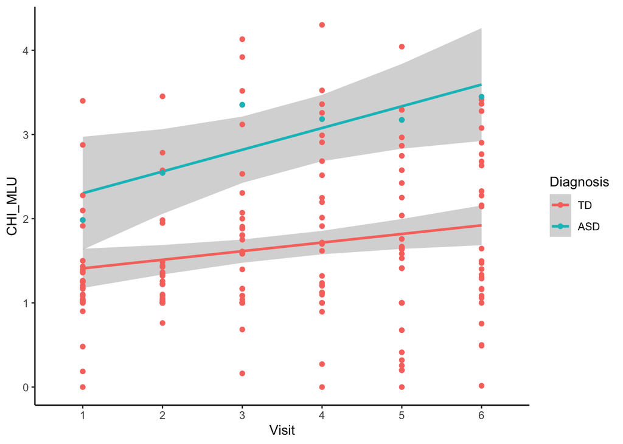

```r
# Renaming and chanching variables to prepare data merge
Bernie<- rename(Bernie, Child.ID=SUBJ)
Bernie<- rename(Bernie, Visit=VISIT)
Bernie$Visit <- str_replace_all(Bernie$Visit, "[:punct:]", "")
Bernie$Visit <- str_extract(Bernie$Visit, "\\d")

TD_All <- select(TD_kids, Child.ID, Visit, Diagnosis, CHI_MLU)
Bern <- select(Bernie, Child.ID, Visit, CHI_MLU)
Bern$Diagnosis <- "ASD"
Bern$Diagnosis <- as.factor(Bern$Diagnosis)
TD_All$Child.ID <- as.character(TD_All$Child.ID)

# Merging dataframes with rbind
Bern_All <- rbind(TD_All, Bern)

# Finally plotting the data
ggplot(Bern_All, aes(x = Visit, y = CHI_MLU, group=Diagnosis, color=Diagnosis))+
         geom_smooth(method = lm)+ geom_point()+ theme_classic()
```

```r
## Predicting Bernie from our model

# Getting Bernie from alle the test data sets
LU_Bernie <- filter(LU_Test, SUBJ == "Bernie.")
Word_Bernie <- filter(Word_Test, SUBJ =="Bernie.")
Demo_Bernie <- filter(Demo_test, Child.ID == "Bernie")

# Chaning coloumn names in Demo
Demo_Bernie <- rename(Demo_Bernie, SUBJ = Child.ID, VISIT = Visit)
LU_Bernie$VISIT <- str_extract(LU_Bernie$VISIT, "\\d")
Word_Bernie$VISIT <- str_extract(Word_Bernie$VISIT, "\\d")

# Removing punctuation in subj colomn
Demo_Bernie$SUBJ <- str_replace_all(Demo_Bernie$SUBJ, "[:punct:]", "")
LU_Bernie$SUBJ <- str_replace_all(LU_Bernie$SUBJ, "[:punct:]", "")
Word_Bernie$SUBJ <- str_replace_all(Word_Bernie$SUBJ, "[:punct:]", "")

# Mergeing alle the Bernies
New_Bernie <- merge(LU_Bernie, Word_Bernie)
New_Bernie <-merge(New_Bernie, Demo_Bernie)

New_Bernie <- rename(New_Bernie, Child.ID = SUBJ, Visit = VISIT)

New_Bernie$Diagnosis <- "ASD"
New_Bernie$Diagnosis <- as.factor(New_Bernie$Diagnosis)
New_Bernie$Visit <- as.integer(New_Bernie$Visit)

New_Bernie <- select(New_Bernie, Child.ID, Visit, Diagnosis, ExpressiveLangRaw, types_CHI, CHI_MLU)

New_Bernie <- subset(New_Bernie, !is.na(CHI_MLU))
New_Bernie <- subset(New_Bernie, !is.na(ExpressiveLangRaw))

#making predictions
M8 <- lmer(CHI_MLU ~ Visit*Diagnosis*ExpressiveLangRaw*types_CHI + (1|Child.ID) + (0+Visit|Child.ID), data = All_Data)
train_Bernie <- predict(M8, newdata=New_Bernie, allow.new.levels = TRUE)
RMSE_bernie=rmse(New_Bernie$CHI_MLU, train_Bernie)
RMSE_bernie #0.40
```

```
## [1] 0.4023098
```

```r
sd(New_Bernie$CHI_MLU) #1.03
```

```
## [1] 1.035174
```

The predictions for Bernie seem to be good, as the RMSE value is 0.4, which is much lower than the standard deviation of the mean (SD = 1.04), which is the NULL-model.

### OPTIONAL: Exercise 4) Model Selection via Information Criteria

Another way to reduce the bad surprises when testing a model on new data is to pay close attention to the relative information criteria between the models you are comparing. Let’s learn how to do that!

Re-create a selection of possible models explaining ChildMLU (the ones you tested for exercise 2, but now trained on the full dataset and not cross-validated).

Then try to find the best possible predictive model of ChildMLU, that is, the one that produces the lowest information criterion.

- Bonus question for the optional exercise: are information criteria correlated with cross-validated RMSE? That is, if you take AIC for Model 1, Model 2 and Model 3, do they co-vary with their cross-validated RMSE?

### OPTIONAL: Exercise 5): Using Lasso for model selection

Welcome to the last secret exercise. If you have already solved the previous exercises, and still there’s not enough for you, you can expand your expertise by learning about penalizations. Check out this tutorial: http://machinelearningmastery.com/penalized-regression-in-r/ and make sure to google what penalization is, with a focus on L1 and L2-norms. Then try them on your data!